# Rhino

2020 데이터사이언스 입문

team 코뿔소

2020-06-17

# 1 About rhino

## 1.1 프로젝트 배경 및 목적

자동차의 등장과 보급은 인류에게 커다란 은혜였습니다. 그러나 현대에 들어, 마냥 좋은 것만은 아니었다는 사실이 속속 드러났습니다. 탄소 에너지는 점점 고갈되고 있으며, 환경파괴는 수많은 문제를 낳고 있습니다. 이미 자동차를 포기할 수 없게 되어버린 인류는 다른 해결책을 찾아야만 했습니다. 저공해의 새로운 에너지원은 인류의 해결책 중 하나였고, 그 중에서도 수소 에너지 또한 거기 해당됩니다. 인류는 다시 해답을 찾아냈고 마침내 수소연료 자동차를 만드는데 성공했습니다. 그 중에서도 **수소전기차**(수소를 이용해 전기를 생산하여 작동하는 방식의 자동차, FCEV)가 우선적으로 개발되었으며, 한국에서 현대자동차에 의해 세계 최초로 상용화 되었습니다.

[figure not shown]

(그림 1 - 현대자동차 ‘넥쏘’)

이렇게 가장 앞선 수소전기차 기술을 보유한 한국은 ‘수소 공화국’이 되어 4차 산업혁명을 선도할 수 있는 위치에 올랐습니다. 그러나 사람들에게 수소전기차는 아직 생소합니다. 그 실상은 수소를 충전할 수 있는 시설이 한국에는 아직 30개 남짓이며, 서울시 내에 설치된 숫자는 3개에 불과합니다(2020.05 기준). 수소차를 운용할 인프라가 구축되지 못한 것입니다. 이에 서울시는 2022년까지 15곳의 수소충전소를 운영하기로 계획했습니다. 수소충전소의 설치는 수소 사회가 다가오면서 점점 늘어날 것입니다. 그에 따라 충전소의 적정 입지에 대한 분석이 필요한 상황입니다. 수소 공급 문제의 해결 과정에서 한국은 미래 에너지 시장에서 더욱 확고한 위치를 점할 수 있을 것입니다.

## 1.2 데이터 및 변수

| 범주 | 변수 | 출처 |
| --- | --- | --- |
| ‘경제적 요인’ | ‘주유소수’ | ‘서울시 열린데이터광장’ |
| ‘경제적 요인’ | ‘차량등록대수’ | ‘서울시 열린데이터광장’ |
| ‘경제적 요인’ | ‘수소전기차 등록대수’ | ‘서울시 열린데이터광장’ |
| ‘경제적 요인’ | ‘사업체수’ | ‘서울시 열린데이터광장’ |
| ‘경제적 요인’ | ‘유통업체수’ | ‘서울시 열린데이터광장’ |
| ‘경제적 요인’ | ‘등록차량수 대비 주유소수’ | ‘파생변수’ |
| ‘인구학적 요인’ | ‘주간인구수’ | ‘서울시 열린데이터광장’ |
| ‘인구학적 요인’ | ‘총생활인구수’ | ‘서울시 열린데이터광장’ |
| ‘인구학적 요인’ | ‘야간인구수’ | ‘서울시 열린데이터광장’ |
| ‘교통요인’ | ‘주차장면적’ | ‘서울시 열린데이터광장’ |
| ‘교통요인’ | ‘유입교통량’ | ‘서울시 열린데이터광장’ |
| ‘교통요인’ | ‘유출교통량’ | ‘서울시 열린데이터광장’ |
| ‘교통요인’ | ‘도로면적’ | ‘서울시 열린데이터광장’ |
| ‘교통요인’ | ‘각 수소충전소와의 거리’ | ‘서울시 열린데이터광장, 구글 어스’ |
| ‘토지이용 요인’ | ‘공시지가’ | ‘서울시 열린데이터광장’ |
| ‘토지이용 요인’ | ‘대학수’ | ‘서울시 열린데이터광장’ |
| ‘토지이용 요인’ | ‘학교수’ | ‘서울시 열린데이터광장’ |

표 1 - 분석에 사용된 변수

## 1.3 분석 방법

서울시를 자치구 기준으로 나누어 수소 충전소 설치의 우선순위를 연구했습니다. 전처리 과정에서 충전소 관련 변수와 차량 관련 변수로 나누어 진행했습니다. 충전소 관련 변수 중 결측치인 강북구의 교통량은 데이터가 있는 자치구들을 분석한 결과, 도로면적과 교통량 간 상관관계가 높은 것으로 파악되어 유일변수로 회귀분석을 실시해 결측치를 채워넣었습니다. 동 기준으로 차량 관련 변수 자료 수집 중에 동의 구분 형태가 행정동과 법정동 두 가지인 것을 확인하고, 이후 데이터를 차량 대수 데이터에 맞추어 자치구 기준으로 변환했습니다. 그 결과 법정동을 기준으로 한 변수가 적고 표본이 많은 데이터와 자치구를 기준으로 한 변수가 많고 표본이 적은 데이터 두 가지가 산출되었습니다. 입지 우선순위를 선정하기 위해 Random Forest, Decision Tree, Bagging, GLM(Generalized Linear Model)를 이용해 변수들과 표본의 상관관계를 분석했습니다. 우선 변수들 각각의 중요도를 분석해 의미 있는 변수들을 파악했습니다. 이것을 바탕으로 수소충전소의 존재가 해당 자치구의 수소자동차 보유량에 미치는 영향을 분석하여 그 중 예측력과 해석력이 나은 모델을 선택했습니다.

# 2 수소전기차의 개념

수소전기차에 대한 한국의 법적 정의는 다음과 같습니다. ‘연료전지 자동차(Fuel Cell Electric Vehicle: FCEV; 약칭 수소전기차)’란 수소를 사용하여 발생시킨 전기에너지를 동력원으로 사용하는 자동차로 정의된다(「환경친화적 자동차의 개발 및 보급 촉진에 관한 법률」(이하 친환경자동차법) 제2조). 사실 수소전기차 이전에 수소를 엔진에서 직접 연소하는 방식의 수소연료 자동차(Hydrogen Fueled Car)가 먼저 연구되었지만, 상대적으로 낮은 효율로 인해 사장되고 말았습니다. 그에 비해 수소연료전지를 통해 구동에너지를 활용할 경우 동급 내연기관 자동차의 2배 정도의 에너지 효율을 보여 수소차의 초점이 수소전기차로 옮겨지게 되었습니다.전기를 이용하는 전기차와 비교해도 긴 주행거리, 짧은 충전시간, 친환경성, 대형차 적용가능성 등으로 인해 많은 관심을 받고 있습니다. 그래서 최근에는 사실상 수소연료전지차가 ‘수소차’의 동의어로 인식되고 있으며, 친환경에너지차량 시장에서 전기차와 함께 각광받는 존재가 되었습니다.

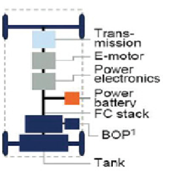

(그림 2 - 수소자동차의 구조)

# 3 데이터 전처리

## 3.1 충전소 관련 데이터 Imputation (파일: imputation.R)

- gasstation.csv(원래 file명 : total_data.csv)중에서 유일하게 강북구의 inflow,유출교통량가 결측치이다.
- road_area와 교통량(inflow,유출교통량) 상관관계 높아서 유일변수로 회귀분석 실시

```
inflow.lm <- lm(inflow~road_area, data=gas_tbl_lm)
outflow.lm <- lm(outflow~road_area, data=gas_tbl_lm)
```

- 강북구 inflow,유출교통량 결측치 채워넣기

```
gas_tbl$inflow[3] <- predict(inflow.lm, newdata = gas_tbl %>% filter(gu == '강북구') %>% select(-gu))
gas_tbl$outflow[3] <- predict(outflow.lm, newdata = gas_tbl %>% filter(gu == '강북구') %>% select(-gu))
```

- gasstation_imputation.csv로 저장하고, 추후 imputation된 파일로 진행

## 3.2 차량 관련데이터

### 3.2.1 전처리 코드 순서 : ( data2(법정동_기준).R -> data2(행정동_기준).R -> preprocessing.R)

- 데이터 병합에 있어서 동 분류 기준이 다르다는 점 확인. (법정동 / 행정동 두 가지로 분류)
- 이후 행정동 기준 데이터는 차량 대수 데이터 확보를 위해 자치구 단위로 합침.

### 3.2.2 최종 전처리 완료 데이터 2가지 산출

- car_v2.csv : 법정동 기준으로 분류, row(데이터)가 많지만 col(변수)이 적음
- car_gu.csv : 자치구 기준으로 분류, row(데이터)가 작지만 col(변수)가 다양함

## 3.3 EDA

- 가공된 데이터를 바탕으로 EDA실행, 결과물들은 [shiny dashbord](https://ysuks.shinyapps.io/dashboard/)에서 확인 가능

```r
A1 <- readr::read_csv('https://raw.githubusercontent.com/statkwon/rhino/master/visualization/Leaflet/data.csv')
library(DT)

datatable(A1,
          caption = "데이터 전처리 결과물",
          filter="top")
```

|  | 구 | SIG_CD | 주유소수 | 등록차량수 | 유입교통량 | 유출교통량 | 공시지가 | 대학수 | 사업체수 | 유통업체수 | 주차장면적 | 학교수 | 도로면적 | 생활인구수 | 주간인구수 | 야간인구수 |
| --- | --- | --- | --- | --- | --- | --- | --- | --- | --- | --- | --- | --- | --- | --- | --- | --- |
| 1 | 강남구 | 11680 | 125 | 235376 | 164634707 | 159410492 | 119 | 3 | 71373 | 255893 | 390191 | 120 | 6700039 | 852709 | 1004121 | 744327 |
| 2 | 강동구 | 11740 | 43 | 143137 | 49936872 | 41439778 | 117 | 1 | 29772 | 114448 | 167853 | 93 | 3729538 | 496114 | 467542 | 516380 |
| 3 | 강북구 | 11305 | 28 | 76265 | 39214634 | 39113800 | 114 | 2 | 18918 | 83831 | 89173 | 59 | 2000480 | 309348 | 284766 | 326815 |
| 4 | 강서구 | 11500 | 73 | 204000 | 36895972 | 31378712 | 118 | 4 | 38524 | 170268 | 260730 | 138 | 3994520 | 561761 | 537358 | 579028 |
| 5 | 관악구 | 11620 | 32 | 119646 | 16043785 | 19963877 | 114 | 3 | 26105 | 72107 | 151070 | 91 | 2607929 | 519174 | 471660 | 552959 |
| 6 | 광진구 | 11215 | 35 | 99089 | 27095066 | 25629685 | 116 | 4 | 24535 | 99408 | 129859 | 78 | 2495694 | 408328 | 392245 | 419694 |
| 7 | 구로구 | 11530 | 50 | 143939 | 35088544 | 35880818 | 114 | 3 | 38553 | 318487 | 178806 | 90 | 2858067 | 429308 | 423531 | 433311 |
| 8 | 금천구 | 11545 | 26 | 87494 | 56337224 | 58033126 | 115 | 1 | 32472 | 328702 | 119994 | 54 | 2022988 | 241880 | 257807 | 230436 |
| 9 | 노원구 | 11350 | 42 | 152172 | 53678782 | 51587379 | 114 | 6 | 26616 | 164758 | 175831 | 163 | 2823777 | 531820 | 500802 | 553823 |
| 10 | 도봉구 | 11320 | 39 | 95969 | 18194048 | 17130948 | 112 | 1 | 18894 | 53923 | 112583 | 73 | 2083240 | 291235 | 270709 | 305809 |

[output cut: 15 more lines]

# 4 Modeling 1 : Variable Importance 파악

## 4.1 의미 : 특정 입지의 충전소 수요

### 4.1.1 Bagging

```
- 중요변수: 사업체 수, 유입교통량, 공시지가, 유출교통량, 대학 수

- R파일: modeling1_bagging2.R
```

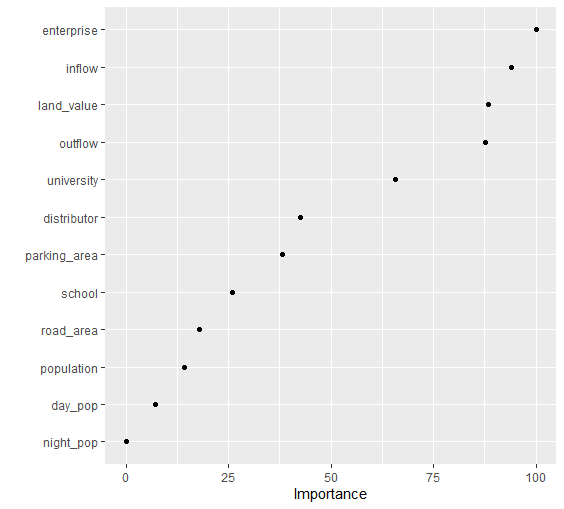

(그림 3 - bagging)

### 4.1.2 Decision Tree

```
- 중요변수: 유입교통량,유출교통량, enterprise, day_pop, distributor

- R파일: modeling1_decisiontree.R
```

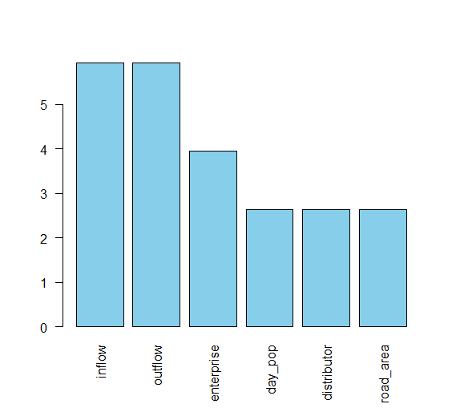

(그림 4 - decision tree)

### 4.1.3 Random Forest

```
- 중요변수: inflow, enterprise,유출교통량, university, distributor

- R파일: modeling1_randomfrest.R
```

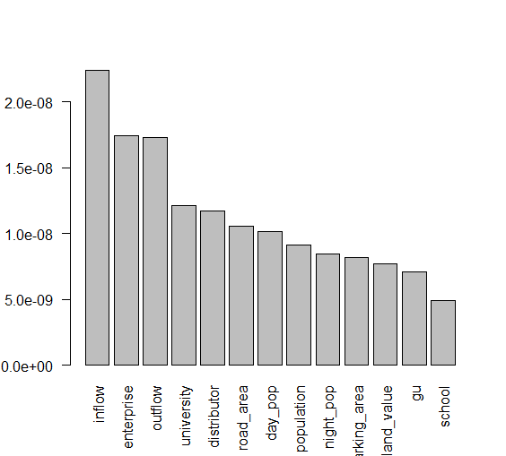

(그림 5 - randomforest)

# 5 Modeling2 : 근거리 수소충전소 변수와 수소차 대수의 상관관계 분석

## 5.1 의미 : 특정 입지의 충전소가 창출하는 수소차의 수요

### 5.1.1 GLM Modeling

```
- 가깝든 멀든 전부 유의미한 상관관계(정도의 차이는 있음)

- R파일: modeling2_glm.R
```

# 6 Modeling3 : 최종예측모델 선정

## 6.1 의미 : 특정 입지의 충전소가 창출하는 수소차의 수요

- 목표: MSE 계산을 통해, 해석력과 예측력을 골고루 갖춘 모형 선택
1. DecisionTree: 27.86282
   - R파일: modeling3_decisiontree.R
2. GLM: 5.76
   - R파일: modeling3_glm2.R
- 결론: MSE가 더 작은 GLM 선택

# 7 최종 모델링

- cv를 이용한 glm 모델 사용
- 새로운 충전소가 추가되었을 때, 가까운 충전소 거리가 최신화 됨을 이용하여 test set 형성

```r
new_gas <- loc_data[loc_data$idx ==150,]
```

- 50번째줄의 숫자를 바꿔서 각 행정동별로 수소차 변동 예측이 확인 가능하다.
- 변화된 test set에 따라서 자치구 별 차량 대수 예측
- 결과 비교 : before/ before_pred / after_pred -> 원래 차량수 / 차량수 예측(현재 기준) / 차량수 예측(충전소가 설치됨을 반영)

## 7.1 순위 산출

```r
#Top5 산출
a <- 0:4 #87번째줄 /Top N 까지 산출하고 싶으면 0:(N-1)로 수정하기
idx <- data.frame(sapply(sort(pred_zip, index.return=TRUE), `[`, length(pred_zip)-a))$ix
loc_data[idx,] %>% select(gu, dong) #쌍문동, 길음동, 창동, 미아동, 하월곡동
```

- 결과: 쌍문동, 길음동, 창동, 미아동, 하월곡동
- 순서대로 도봉구, 성북구, 도봉구, 강북구, 성북구
- Top 5가 아니라 Top N 까지 산출하고 싶으면, 87번째줄 수정하기

# 8 아쉬운 부분

## 8.1 모델링 습작들

- 습작1. modeling1_adaboost.R: Error in if (nrow(object$splits) > 0) { : 인자의 길이가 0입니다
- 습작2. modeling1_bagging.R: Error in if (nrow(object$splits) > 0) { : 인자의 길이가 0입니다
- 습작3. modeling1_bagging3.R
- 습작4. modeling3_glm.R: glm2를 위한 초석
- 습작5. modeling3_glm3.R: 부적절한 설명변수가 너무 많았다.

# 9 Contact

**Rhino github page에서 당신도 Rhino에 참여하실 수 있습니다.**

**[Rhino shiny dashbord](https://ysuks.shinyapps.io/dashboard/)에서 Rhino의 분석결과를 확인할 수 있습니다.**

**[Rhino blog](https://rhinoblog.netlify.app/)**